# Homework 4 and 5

### 2017402168

- In this homework, we are asked to develop alternative forecasting strategies for our project data which is the sales data and the related information of nine products of Trendyol at different categories. I'm going to investigate the seasonality for each product at different levels such as daily, weekly or monthly. Then I am going to fit the data into ARIMA model based on my findings about seasonality. Lastly, in the third and in the last task, I will check for external regressors and whether I can use them in my model or not.
- We decided to work on the project as a group.I am responsible for the last three product in the product list in the project description but I am normally responsible for first three products. We thought that it might be efficient to exchange our products to come up with different and better models.
- For each data, I used Pandas dataframe for manipulation and matplotlib and seaborn for visualization. Basic manupulations I did were importing data, converting excel data into data frame, changing column name, changing index to time series and dropping irrelevant information that data set has given.
- For the ARIMA models and decompositions, I used the statsmodel library.

# Product 1

# Task 1- Analyzing Seasonality

## 1 ) Importing and Manipulating the data for the first three product

- After importing the recent data and deleting unnecessary columns, I changed the event_date column into datetime object to extract month,day,week infromation quickly. Then, I set the event_date column to index to make it time series object. Lastly, I added the month, week and day information as a numeric variable for possiblity of using in future model.

```python
import pandas as pd
import numpy as np
import seaborn as sns
import matplotlib.pyplot as plt
from datetime import datetime
```

```python
import warnings
warnings.filterwarnings('ignore')
```

```python
pr7 = pd.read_csv("alldata_item7.csv")
```

```python
pr7["event_date"] = pd.to_datetime(pr7["event_date"], format = "%d/%m/%Y") # converting event date into datetime object
pr7['Month'] = pr7['event_date'].dt.month #adding month information as a numeric variable
pr7.drop('Unnamed: 0',axis='columns', inplace=True)
pr7['Day'] = pr7['event_date'].dt.weekday #adding day information as a numeric variable
pr7.set_index("event_date" , inplace = True) # setting index time series
pr7.head()
```

| event_date | price | product_content_id | sold_count | visit_count | favored_count | basket_count | category_sold | category_brand_sold | category_visits | ty_visits | category_basket | category_favored | w_day | Month | weeknumber | Day |
| --- | --- | --- | --- | --- | --- | --- | --- | --- | --- | --- | --- | --- | --- | --- | --- | --- |
| 2021-06-18 | 87.14 | 85004 | 57 | 2144 | 299 | 271 | 2772 | 286 | 114848 | 91784941 | 14440 | 15512 | Fri | 6 | 24 | 4 |
| 2021-06-17 | 86.78 | 85004 | 79 | 2729 | 538 | 332 | 2927 | 350 | 117287 | 102409626 | 14701 | 15084 | Thu | 6 | 24 | 3 |
| 2021-06-16 | 87.42 | 85004 | 81 | 2850 | 408 | 336 | 3154 | 360 | 134400 | 105918459 | 16617 | 18419 | Wed | 6 | 24 | 2 |
| 2021-06-15 | 88.08 | 85004 | 78 | 2989 | 423 | 344 | 3504 | 389 | 137894 | 103541571 | 17365 | 19431 | Tue | 6 | 24 | 1 |
| 2021-06-14 | 89.20 | 85004 | 47 | 2796 | 458 | 298 | 3159 | 295 | 139775 | 107738598 | 17284 | 19610 | Mon | 6 | 24 | 0 |

- For time series analysis, I only deal with the sold amount of the product so I drop possible regressors

```python
sold = pd.DataFrame(pr7.sold_count)
sold.head()
```

| event_date | sold_count |
| --- | --- |
| 2021-06-18 | 57 |
| 2021-06-17 | 79 |
| 2021-06-16 | 81 |
| 2021-06-15 | 78 |
| 2021-06-14 | 47 |

# 2 ) Visualizations

- At first, since there are some dramatic peaks at some point, I wanted to check whether there is outlier points in the data or not. So I plotted the boxplot of the sold amount data. From the plot, it seems that there are some outlier points. If the model I am going to fit is not explaining those points. I might discard them.

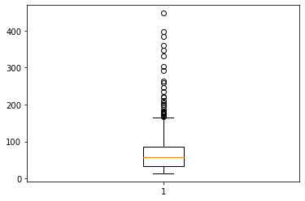

```python
plt.boxplot(sold);
```

- For initial observation, I plotted the sold_count data over time. At first sight, seasonality component seems to be exist but further examination was needed. So, I used ACF and PACF plots. From ACF, we see that there is a seasonality pattern in the data.

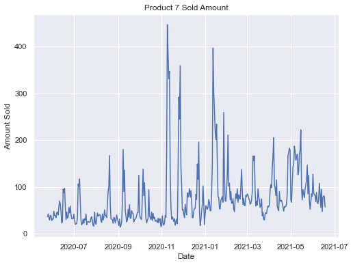

```python
sns.set(rc={'figure.figsize':(8,6)})
plt.title("Product 7 Sold Amount")
plt.xlabel("Date")
plt.ylabel("Amount Sold")
plt.plot(sold)
plt.show();
```

### ACF Plot

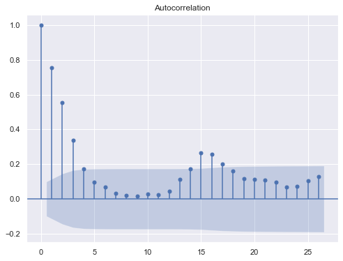

```python
from statsmodels.graphics.tsaplots import plot_acf
plot_acf(sold)
plt.show()
```

### PACF Plot

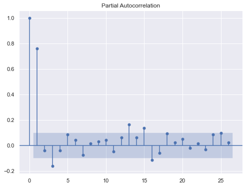

```python
from statsmodels.graphics.tsaplots import plot_pacf
plot_pacf(sold)
plt.show()
```

# 3 ) Decomposing the data

### Weekly Decomposition

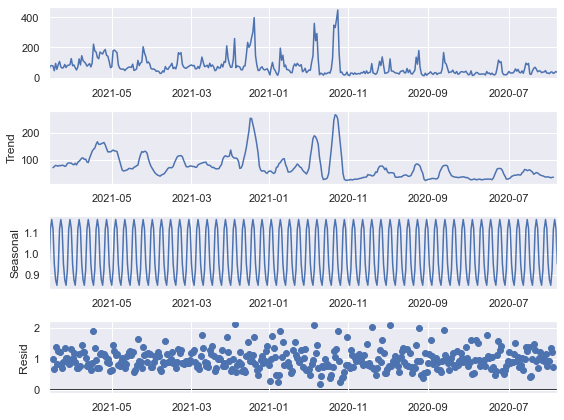

```python
from statsmodels.tsa.seasonal import seasonal_decompose
result = seasonal_decompose(sold, model='multiplicative', period = 7 )
result.plot()
plt.show();
```

### Monthly Seasonality

- Wee again see a seasonal component in the monthly decomposition however again it is hard to say that there is clear trend pattern.

### Monthly Decompositon

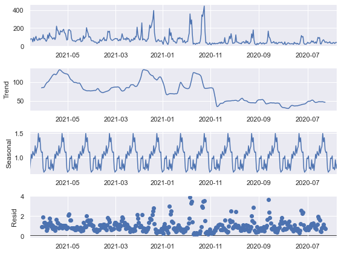

```python
result = seasonal_decompose(sold, model='multiplicative', period = 30 )
result.plot()
plt.show();
```

### Random term after decomposing weekly

[figure not shown]

```python
plt.title("Random Term of Weekly Decomposed Data")
result.resid.plot()
plt.show();
```

### Random term after decomposing monthly

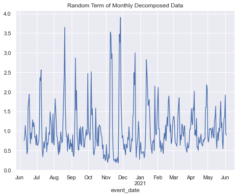

```python
plt.title("Random Term of Monthly Decomposed Data")
result.resid.plot()
plt.show();
```

## Conclusion

- Both the monthly and the weekly decompositon seems to have a significant seasonal component but the trend variables are not significant. We might use weekly decompositon as the random term of weekly decomposition seems more like white noise series.

```python
random = result.resid
trend = result.trend
season = result.seasonal
```

# Task 2- Fitting data into ARIMA Model

## 1 ) Deciding on the parameters

- To decide on the parameters of the ARIMA model, I checked the ACF and PACF plots of the random term. ACF plot has a sinusodial pattern and PACF function has a negative and big correlation at lag 3.I am going to check the neighborhood to find the best model.

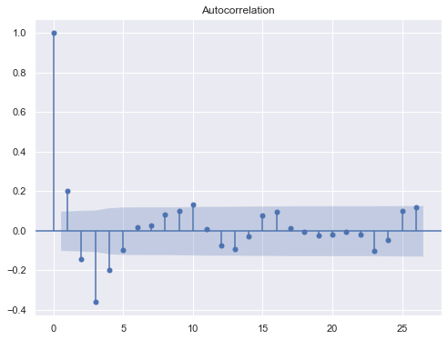

```python
from statsmodels.graphics.tsaplots import plot_acf
plot_acf(random.dropna())
plt.show();
```

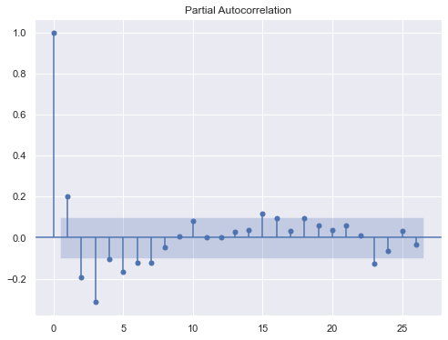

```python
from statsmodels.graphics.tsaplots import plot_pacf
plot_pacf(random.dropna())
plt.show();
```

```python
from statsmodels.tsa.arima.model import ARIMA
model = ARIMA(random, order=(1,0,0))
model_fit = model.fit()
model_fit.aic
```

```
218.40685839191656
```

```python
from statsmodels.tsa.arima.model import ARIMA
model = ARIMA(random, order=(2,0,0))
model_fit = model.fit()
model_fit.aic
```

```
206.20236680279686
```

```python
from statsmodels.tsa.arima.model import ARIMA
model = ARIMA(random, order=(3,0,0))
model_fit = model.fit()
model_fit.aic
```

```
168.58304774456144
```

```python
from statsmodels.tsa.arima.model import ARIMA
model = ARIMA(random, order=(4,0,0))
model_fit = model.fit()
model_fit.aic
```

```
166.5287233764691
```

```python
from statsmodels.tsa.arima.model import ARIMA
model = ARIMA(random, order=(5,0,0))
model_fit = model.fit()
model_fit.aic
```

```
158.11480444172804
```

```python
from statsmodels.tsa.arima.model import ARIMA
model = ARIMA(random, order=(6,0,0))
model_fit = model.fit()
model_fit.aic
```

```
154.54292525862505
```

```python
from statsmodels.tsa.arima.model import ARIMA
model = ARIMA(random, order=(1,0,1))
model_fit = model.fit()
model_fit.aic
```

```
216.79824627485934
```

```python
from statsmodels.tsa.arima.model import ARIMA
model = ARIMA(random, order=(2,0,1))
model_fit = model.fit()
model_fit.aic
```

```
160.36524645231
```

```python
from statsmodels.tsa.arima.model import ARIMA
model = ARIMA(random, order=(3,0,1))
model_fit = model.fit()
model_fit.aic
```

```
152.27543596967428
```

```python
from statsmodels.tsa.arima.model import ARIMA
model = ARIMA(random, order=(4,0,1))
model_fit = model.fit()
model_fit.aic
```

```
153.76869379975648
```

```python
from statsmodels.tsa.arima.model import ARIMA
model = ARIMA(random, order=(2,0,2))
model_fit = model.fit()
model_fit.aic
```

```
152.85075232008083
```

```python
from statsmodels.tsa.arima.model import ARIMA
model = ARIMA(random, order=(1,0,3))
model_fit = model.fit()
model_fit.aic
```

```
161.58088579806216
```

```python
from statsmodels.tsa.arima.model import ARIMA
model = ARIMA(random, order=(2,0,4))
model_fit = model.fit()
model_fit.aic
```

```
136.46567548261407
```

## 2 ) Fitting the Model

```python
from statsmodels.tsa.arima.model import ARIMA
model = ARIMA(random, order=(2,0,4))
model_fit = model.fit()
model_fit.summary()
```

SARIMAX Results

| Dep. Variable: | resid | No. Observations: | 390 |
| --- | --- | --- | --- |
| Model: | ARIMA(2, 0, 4) | Log Likelihood | -60.233 |
| Date: | Wed, 30 Jun 2021 | AIC | 136.466 |
| Time: | 13:19:00 | BIC | 168.195 |
| Sample: | 0 | HQIC | 149.043 |
|  | - 390 |  |  |
| Covariance Type: | opg |  |  |

|  | coef | std err | z | P>\|z\| | [0.025 | 0.975] |
| --- | --- | --- | --- | --- | --- | --- |
| const | 0.9769 | 0.012 | 81.208 | 0.000 | 0.953 | 1.000 |
| ar.L1 | 1.3499 | 0.086 | 15.772 | 0.000 | 1.182 | 1.518 |
| ar.L2 | -0.5303 | 0.082 | -6.428 | 0.000 | -0.692 | -0.369 |
| ma.L1 | -1.2979 | 0.089 | -14.635 | 0.000 | -1.472 | -1.124 |
| ma.L2 | 0.2210 | 0.114 | 1.935 | 0.053 | -0.003 | 0.445 |
| ma.L3 | -0.0766 | 0.107 | -0.714 | 0.475 | -0.287 | 0.134 |
| ma.L4 | 0.2772 | 0.074 | 3.739 | 0.000 | 0.132 | 0.422 |
| sigma2 | 0.0798 | 0.005 | 15.785 | 0.000 | 0.070 | 0.090 |

| Ljung-Box (L1) (Q): | 0.00 | Jarque-Bera (JB): | 56.86 |
| --- | --- | --- | --- |
| Prob(Q): | 0.99 | Prob(JB): | 0.00 |
| Heteroskedasticity (H): | 1.64 | Skew: | 0.65 |
| Prob(H) (two-sided): | 0.01 | Kurtosis: | 4.34 |

Warnings:  
[1] Covariance matrix calculated using the outer product of gradients (complex-step).

### Residuals after fitting

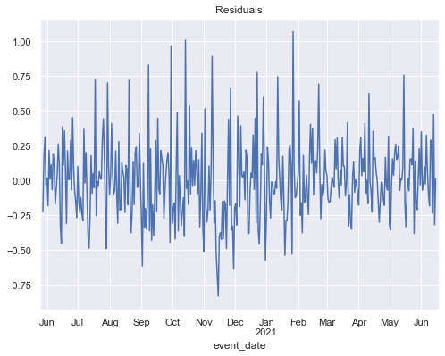

```python
plt.title("Residuals")
model_fit.resid.plot();
plt.show()
```

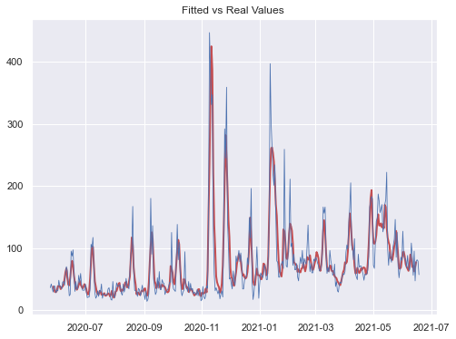

```python
new_df = pd.DataFrame(model_fit.fittedvalues * trend*season,  index = model_fit.fittedvalues.index)
new_df.columns = ["Fitted"]
new_df["Real"] = sold
plt.plot(random.index,new_df.Fitted, c = "r",linewidth=2)
plt.plot(random.index,new_df.Real, c = "b", linewidth=0.8,)
plt.title("Fitted vs Real Values ")
plt.show()
```

# Task 3 and 4 - Adding external regressors to the model

## 1 ) Searcing for regressors

- In this part, I am going to look for variables that might be correlated to sold amount and can be used as regressors in the ARIMAX model. To do this, first I am going to use pairplots. But some of the data in the columns are lost for so many data points. So only columns I can use for this, "Basket Count" , "Category Sold" , Category Visits" and "Category Favored". I checked the relation of each variable with the sold count. From the visualizations, Basket Count and Category Favored seems to have a correlation, so I am going to add those variables to the model.

### Pair Plot

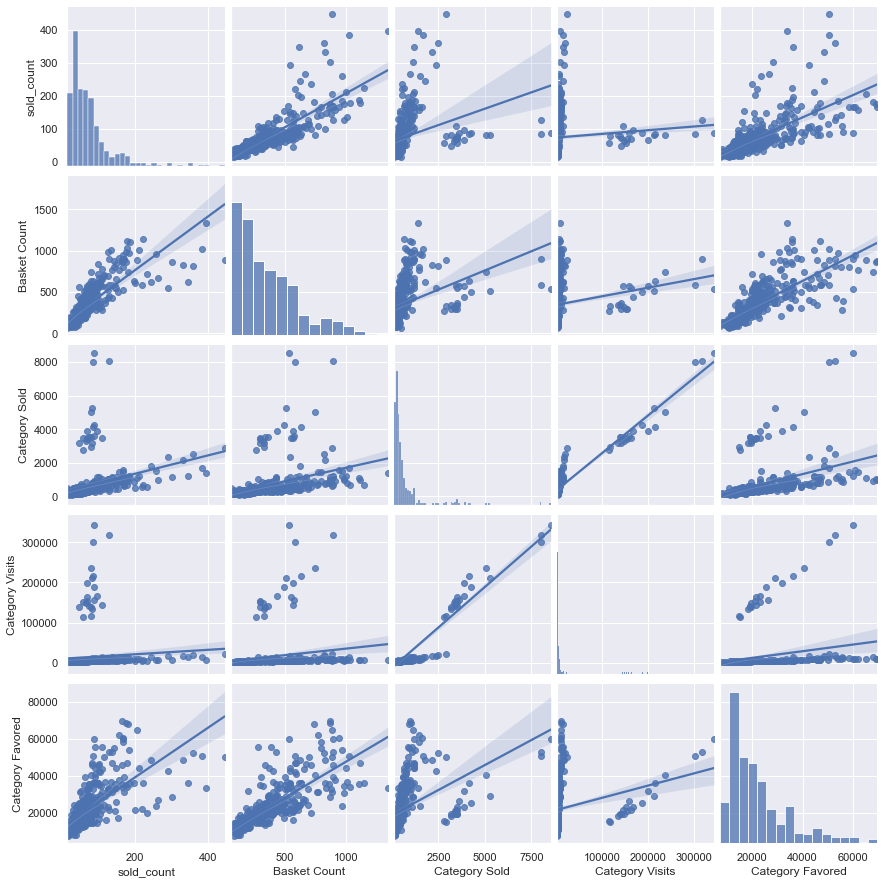

```python
pairplot = pd.DataFrame(pr7["sold_count"])
pairplot["Basket Count"] = pr7["basket_count"]
pairplot["Category Sold"] = pr7["category_sold"]
pairplot["Category Visits"] = pr7["category_visits"]
pairplot["Category Favored"] = pr7["category_favored"]
sns.pairplot(pairplot, kind = "reg");
```

## 2 ) Adding regressors to the ARIMA model

- Before creating a regressors matrix, I had to split my data into train and test data so that I can calculate some performance measures. To do that, I am allocating the last seven days as test data and the rest as train data.

```python
train_data = sold.drop(sold.head(7).index)
train_data
```

| event_date | sold_count |
| --- | --- |
| 2021-06-11 | 87 |
| 2021-06-10 | 108 |
| 2021-06-09 | 73 |
| 2021-06-08 | 64 |
| 2021-06-07 | 68 |
| ... | ... |
| 2020-05-29 | 39 |
| 2020-05-28 | 29 |
| 2020-05-27 | 35 |
| 2020-05-26 | 42 |
| 2020-05-25 | 36 |

383 rows × 1 columns

```python
test_data = sold.head(7)
test_data.head()
```

| event_date | sold_count |
| --- | --- |
| 2021-06-18 | 57 |
| 2021-06-17 | 79 |
| 2021-06-16 | 81 |
| 2021-06-15 | 78 |
| 2021-06-14 | 47 |

```python
regressors = pd.DataFrame(pr7["basket_count"].drop(pr7.head(7).index))
#regressors["Category Favored"] = pr7["category_favored"].drop(pr7.head(7).index)
regressors.head()
```

| event_date | basket_count |
| --- | --- |
| 2021-06-11 | 577 |
| 2021-06-10 | 571 |
| 2021-06-09 | 363 |
| 2021-06-08 | 322 |
| 2021-06-07 | 298 |

### Now I need to decompose my train data and fit the model with and without external regressors.

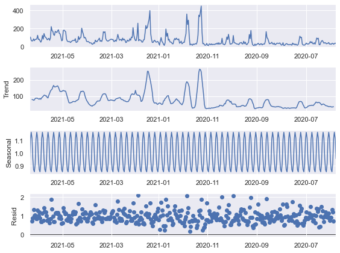

```python
from statsmodels.tsa.seasonal import seasonal_decompose
result = seasonal_decompose(train_data, model='multiplicative', period = 7 )
trend = result.trend
season = result.seasonal
random = result.resid
result.plot();
```

### Without regressors

```python
from statsmodels.tsa.arima.model import ARIMA
model = ARIMA(random, order=(2,0,4))
model_fit = model.fit()
model_fit.summary()
```

SARIMAX Results

| Dep. Variable: | resid | No. Observations: | 383 |
| --- | --- | --- | --- |
| Model: | ARIMA(2, 0, 4) | Log Likelihood | -59.781 |
| Date: | Wed, 30 Jun 2021 | AIC | 135.563 |
| Time: | 13:21:46 | BIC | 167.147 |
| Sample: | 0 | HQIC | 148.092 |
|  | - 383 |  |  |
| Covariance Type: | opg |  |  |

|  | coef | std err | z | P>\|z\| | [0.025 | 0.975] |
| --- | --- | --- | --- | --- | --- | --- |
| const | 0.9760 | 0.012 | 80.962 | 0.000 | 0.952 | 1.000 |
| ar.L1 | 1.3511 | 0.086 | 15.755 | 0.000 | 1.183 | 1.519 |
| ar.L2 | -0.5323 | 0.083 | -6.413 | 0.000 | -0.695 | -0.370 |
| ma.L1 | -1.2901 | 0.089 | -14.544 | 0.000 | -1.464 | -1.116 |
| ma.L2 | 0.2087 | 0.114 | 1.825 | 0.068 | -0.015 | 0.433 |
| ma.L3 | -0.0714 | 0.108 | -0.663 | 0.508 | -0.282 | 0.140 |
| ma.L4 | 0.2766 | 0.074 | 3.723 | 0.000 | 0.131 | 0.422 |
| sigma2 | 0.0801 | 0.005 | 15.649 | 0.000 | 0.070 | 0.090 |

| Ljung-Box (L1) (Q): | 0.00 | Jarque-Bera (JB): | 55.51 |
| --- | --- | --- | --- |
| Prob(Q): | 1.00 | Prob(JB): | 0.00 |
| Heteroskedasticity (H): | 1.53 | Skew: | 0.65 |
| Prob(H) (two-sided): | 0.02 | Kurtosis: | 4.33 |

Warnings:  
[1] Covariance matrix calculated using the outer product of gradients (complex-step).

### With external regressor

```python
from statsmodels.tsa.arima.model import ARIMA
model = ARIMA(random, order=(2,0,4), exog = regressors)
model_fit = model.fit()
model_fit.summary()
```

SARIMAX Results

| Dep. Variable: | resid | No. Observations: | 383 |
| --- | --- | --- | --- |
| Model: | ARIMA(2, 0, 4) | Log Likelihood | -82.536 |
| Date: | Wed, 30 Jun 2021 | AIC | 185.072 |
| Time: | 13:22:57 | BIC | 224.553 |
| Sample: | 0 | HQIC | 200.734 |
|  | - 383 |  |  |
| Covariance Type: | opg |  |  |

[output not shown]

| Ljung-Box (L1) (Q): | 23.75 | Jarque-Bera (JB): | 45.65 |
| --- | --- | --- | --- |
| Prob(Q): | 0.00 | Prob(JB): | 0.00 |
| Heteroskedasticity (H): | 1.58 | Skew: | 0.76 |
| Prob(H) (two-sided): | 0.01 | Kurtosis: | 3.76 |

Warnings:  
[1] Covariance matrix calculated using the outer product of gradients (complex-step).  
[2] Covariance matrix is singular or near-singular, with condition number 1.07e+17. Standard errors may be unstable.

```python
from statsmodels.tsa.arima.model import ARIMA
model = ARIMA(random, order=(3,0,1), exog = regressors)
model_fit = model.fit()
model_fit.summary()
```

SARIMAX Results

| Dep. Variable: | resid | No. Observations: | 383 |
| --- | --- | --- | --- |
| Model: | ARIMA(3, 0, 1) | Log Likelihood | -57.092 |
| Date: | Wed, 30 Jun 2021 | AIC | 128.184 |
| Time: | 13:24:26 | BIC | 155.820 |
| Sample: | 0 | HQIC | 139.147 |
|  | - 383 |  |  |
| Covariance Type: | opg |  |  |

|  | coef | std err | z | P>\|z\| | [0.025 | 0.975] |
| --- | --- | --- | --- | --- | --- | --- |
| const | 0.7856 | 0.030 | 26.130 | 0.000 | 0.727 | 0.845 |
| basket_count | 0.0005 | 6.7e-05 | 7.584 | 0.000 | 0.000 | 0.001 |
| ar.L1 | 0.1390 | 0.236 | 0.588 | 0.557 | -0.325 | 0.602 |
| ar.L2 | -0.0206 | 0.084 | -0.245 | 0.807 | -0.185 | 0.144 |
| ar.L3 | -0.2128 | 0.057 | -3.733 | 0.000 | -0.325 | -0.101 |
| ma.L1 | 0.1209 | 0.246 | 0.491 | 0.623 | -0.361 | 0.603 |
| sigma2 | 0.0800 | 0.006 | 13.585 | 0.000 | 0.068 | 0.091 |

| Ljung-Box (L1) (Q): | 0.01 | Jarque-Bera (JB): | 59.51 |
| --- | --- | --- | --- |
| Prob(Q): | 0.91 | Prob(JB): | 0.00 |
| Heteroskedasticity (H): | 1.85 | Skew: | 0.84 |
| Prob(H) (two-sided): | 0.00 | Kurtosis: | 3.94 |

Warnings:  
[1] Covariance matrix calculated using the outer product of gradients (complex-step).

```python
from statsmodels.tsa.arima.model import ARIMA
model = ARIMA(random, order=(3,0,0), exog = regressors)
model_fit = model.fit()
model_fit.summary()
```

SARIMAX Results

| Dep. Variable: | resid | No. Observations: | 383 |
| --- | --- | --- | --- |
| Model: | ARIMA(3, 0, 0) | Log Likelihood | -57.620 |
| Date: | Wed, 30 Jun 2021 | AIC | 127.239 |
| Time: | 13:41:27 | BIC | 150.928 |
| Sample: | 0 | HQIC | 136.636 |
|  | - 383 |  |  |
| Covariance Type: | opg |  |  |

|  | coef | std err | z | P>\|z\| | [0.025 | 0.975] |
| --- | --- | --- | --- | --- | --- | --- |
| const | 0.7856 | 0.028 | 27.694 | 0.000 | 0.730 | 0.841 |
| basket_count | 0.0005 | 6.38e-05 | 7.903 | 0.000 | 0.000 | 0.001 |
| ar.L1 | 0.2598 | 0.054 | 4.797 | 0.000 | 0.154 | 0.366 |
| ar.L2 | -0.0547 | 0.055 | -1.002 | 0.316 | -0.162 | 0.052 |
| ar.L3 | -0.1993 | 0.056 | -3.586 | 0.000 | -0.308 | -0.090 |
| sigma2 | 0.0798 | 0.006 | 13.607 | 0.000 | 0.068 | 0.091 |

| Ljung-Box (L1) (Q): | 0.01 | Jarque-Bera (JB): | 60.91 |
| --- | --- | --- | --- |
| Prob(Q): | 0.94 | Prob(JB): | 0.00 |
| Heteroskedasticity (H): | 1.87 | Skew: | 0.85 |
| Prob(H) (two-sided): | 0.00 | Kurtosis: | 3.95 |

Warnings:  
[1] Covariance matrix calculated using the outer product of gradients (complex-step).

## Comments

- So overall model has improved with the external regressor Basket Count. But the AR(2) term has become insignificant. I am going to continue with this model.

## Forecasting and model performance measures

```python
forecast = model_fit.forecast(steps = 7, exog = pr7["basket_count"].head(7))
```

```python
trend = trend.fillna(79.428571)  #this value is the last trend value so I filled NA values with the last trend value
trend_comp = trend.head(7).values
season_comp = list(season[371:378])
season_comp.reverse()
```

```python
forecast_normalized = forecast.values*trend_comp*season_comp
```

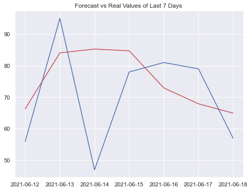

```python
plt.plot(test_data.index,forecast_normalized, c = "r")
plt.plot(test_data.index,test_data, c = "b")
plt.title("Forecast vs Real Values of Last 7 Days ")
plt.show()
```

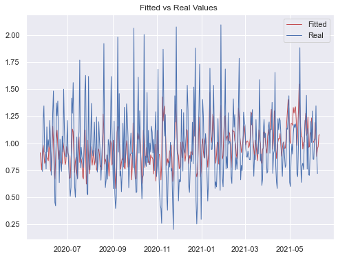

```python
new_df = pd.DataFrame(model_fit.fittedvalues,  index = model_fit.fittedvalues.index)
new_df.columns = ["Fitted"]
new_df["Real"] = random
plt.plot(train_data.index,new_df.Fitted, c = "r",linewidth=1, label = "Fitted")
plt.plot(train_data.index,new_df.Real, c = "b", linewidth=1, label = "Real")
plt.title("Fitted vs Real Values ")
plt.legend()
plt.show()
```

## Conclusion

### Overall looking the model, I would definetely go with an LM model as I did in the project becuase external regressors are covering the variance highly as opposed to the ARIMA model.

# Product 2

- For the product 2, I followed the same steps of product 1. Therefore, I am going to skip the descriptive comments and keep the related ones only.

# Task 1- Analyzing Seasonality

## 1 ) Importing and Manipulating the data for the first three product

```python
pr8 = pd.read_csv("alldata_item8.csv")
```

```python
pr8["event_date"] = pd.to_datetime(pr8["event_date"], format = "%d/%m/%Y") # converting event date into datetime object
pr8['Month'] = pr8['event_date'].dt.month #adding month information as a numeric variable
pr8.drop('Unnamed: 0',axis='columns', inplace=True)
pr8['Day'] = pr8['event_date'].dt.weekday #adding day information as a numeric variable
pr8.set_index("event_date" , inplace = True) # setting index time series
pr8.head()
```

| event_date | price | product_content_id | sold_count | visit_count | favored_count | basket_count | category_sold | category_brand_sold | category_visits | ty_visits | category_basket | category_favored | w_day | Month | weeknumber | Day |
| --- | --- | --- | --- | --- | --- | --- | --- | --- | --- | --- | --- | --- | --- | --- | --- | --- |
| 2021-06-18 | 67.92 | 4066298 | 2362 | 28495 | 1774 | 6862 | 10011 | 8616 | 140196 | 91784941 | 31630 | 11462 | Fri | 6 | 24 | 4 |
| 2021-06-17 | 72.50 | 4066298 | 494 | 5535 | 344 | 1407 | 3575 | 1919 | 49818 | 102409626 | 11647 | 3949 | Thu | 6 | 24 | 3 |
| 2021-06-16 | 72.53 | 4066298 | 383 | 4782 | 231 | 1140 | 3721 | 1822 | 53000 | 105918459 | 13130 | 4131 | Wed | 6 | 24 | 2 |
| 2021-06-15 | 72.56 | 4066298 | 381 | 4325 | 226 | 880 | 3779 | 1819 | 50480 | 103541571 | 11154 | 4093 | Tue | 6 | 24 | 1 |
| 2021-06-14 | 72.67 | 4066298 | 269 | 3867 | 226 | 773 | 3099 | 1355 | 47481 | 107738598 | 10059 | 4170 | Mon | 6 | 24 | 0 |

```python
sold = pd.DataFrame(pr8.sold_count)
sold.head()
```

| event_date | sold_count |
| --- | --- |
| 2021-06-18 | 2362 |
| 2021-06-17 | 494 |
| 2021-06-16 | 383 |
| 2021-06-15 | 381 |
| 2021-06-14 | 269 |

# 2 ) Visualizations

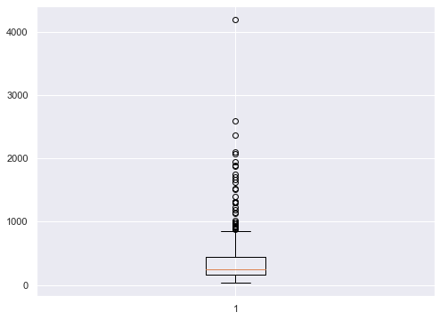

```python
plt.boxplot(sold);
```

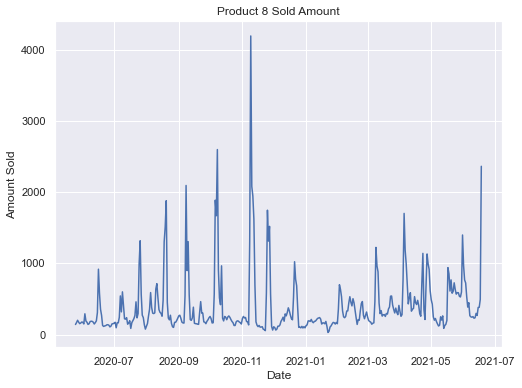

```python
sns.set(rc={'figure.figsize':(8,6)})
plt.title("Product 8 Sold Amount")
plt.xlabel("Date")
plt.ylabel("Amount Sold")
plt.plot(sold)
plt.show();
```

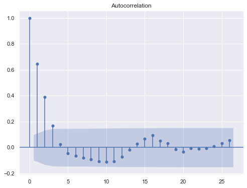

```python
from statsmodels.graphics.tsaplots import plot_acf
plot_acf(sold)
plt.show()
```

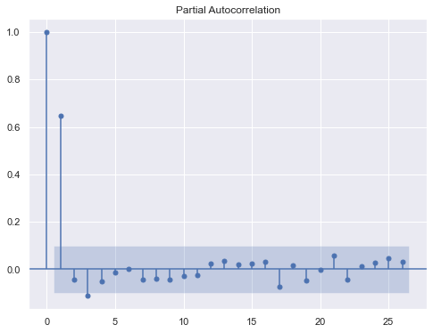

```python
from statsmodels.graphics.tsaplots import plot_pacf
plot_pacf(sold)
plt.show()
```

# 3 ) Decomposing the data

### Weekly Seasonality

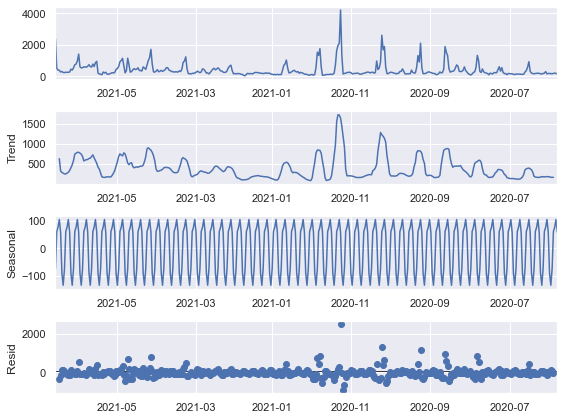

```python
from statsmodels.tsa.seasonal import seasonal_decompose
result = seasonal_decompose(sold, model='additive', period = 7 )
result.plot()
plt.show();
```

### Monthly Seasonality

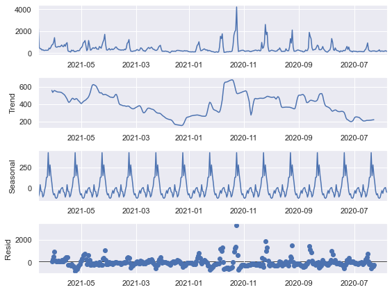

```python
result = seasonal_decompose(sold, model='additive', period = 30 )
result.plot()
plt.show();
```

### Random term after decomposing weekly

[figure not shown]

```python
plt.title("Random Term of Weekly Decomposed Data")
result.resid.plot()
plt.show();
```

### Random term after decomposing monthly

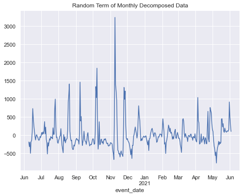

```python
plt.title("Random Term of Monthly Decomposed Data")
result.resid.plot()
plt.show();
```

## Conclusion

- Both the monthly and the weekly decompositon seems to have a significant seasonal component but the trend variables are not significant. We might use weekly decompositon as the random term of weekly decomposition seems more like white noise series.

```python
random = result.resid
trend = result.trend
season = result.seasonal
```

# Task 2- Fitting data into ARIMA Model

## 1 ) Deciding on the parameters

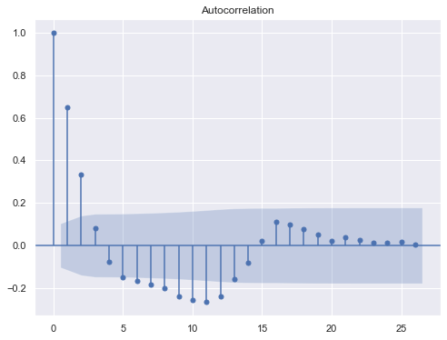

```python
plot_acf(random.dropna())
plt.show();
```

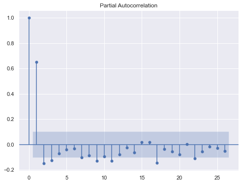

```python
plot_pacf(random.dropna())
plt.show();
```

```python
from statsmodels.tsa.arima.model import ARIMA
model = ARIMA(random, order=(1,0,0))
model_fit = model.fit()
model_fit.aic
```

```
5138.5872579561465
```

```python
from statsmodels.tsa.arima.model import ARIMA
model = ARIMA(random, order=(2,0,0))
model_fit = model.fit()
model_fit.aic
```

```
5132.689998375536
```

```python
from statsmodels.tsa.arima.model import ARIMA
model = ARIMA(random, order=(3,0,0))
model_fit = model.fit()
model_fit.aic
```

```
5129.09573837819
```

```python
from statsmodels.tsa.arima.model import ARIMA
model = ARIMA(random, order=(4,0,0))
model_fit = model.fit()
model_fit.aic
```

```
5129.370188868617
```

```python
from statsmodels.tsa.arima.model import ARIMA
model = ARIMA(random, order=(1,0,1))
model_fit = model.fit()
model_fit.aic
```

```
5134.869571686347
```

```python
from statsmodels.tsa.arima.model import ARIMA
model = ARIMA(random, order=(2,0,1))
model_fit = model.fit()
model_fit.aic
```

```
5086.24682578308
```

```python
from statsmodels.tsa.arima.model import ARIMA
model = ARIMA(random, order=(3,0,1))
model_fit = model.fit()
model_fit.aic
```

```
5088.205288219444
```

```python
from statsmodels.tsa.arima.model import ARIMA
model = ARIMA(random, order=(4,0,1))
model_fit = model.fit()
model_fit.aic
```

```
5090.132150119928
```

```python
from statsmodels.tsa.arima.model import ARIMA
model = ARIMA(random, order=(3,0,2))
model_fit = model.fit()
model_fit.aic
```

```
5089.218216343601
```

```python
from statsmodels.tsa.arima.model import ARIMA
model = ARIMA(random, order=(2,0,2))
model_fit = model.fit()
model_fit.aic
```

```
5088.203412499372
```

```python
from statsmodels.tsa.arima.model import ARIMA
model = ARIMA(random, order=(1,0,2))
model_fit = model.fit()
model_fit.aic
```

```
5133.109874633149
```

## 2 ) Fitting the Model

```python
from statsmodels.tsa.arima.model import ARIMA
model = ARIMA(random, order=(3,0,1))
model_fit = model.fit()
model_fit.summary()
```

SARIMAX Results

| Dep. Variable: | resid | No. Observations: | 390 |
| --- | --- | --- | --- |
| Model: | ARIMA(3, 0, 1) | Log Likelihood | -2538.103 |
| Date: | Wed, 30 Jun 2021 | AIC | 5088.205 |
| Time: | 14:00:57 | BIC | 5112.002 |
| Sample: | 0 | HQIC | 5097.639 |
|  | - 390 |  |  |
| Covariance Type: | opg |  |  |

|  | coef | std err | z | P>\|z\| | [0.025 | 0.975] |
| --- | --- | --- | --- | --- | --- | --- |
| const | 0.3431 | 1.711 | 0.201 | 0.841 | -3.010 | 3.697 |
| ar.L1 | 1.5861 | 0.026 | 61.346 | 0.000 | 1.535 | 1.637 |
| ar.L2 | -0.6870 | 0.050 | -13.835 | 0.000 | -0.784 | -0.590 |
| ar.L3 | -0.0108 | 0.035 | -0.309 | 0.757 | -0.079 | 0.058 |
| ma.L1 | -1.0000 | 0.036 | -27.712 | 0.000 | -1.071 | -0.929 |
| sigma2 | 7.68e+04 | 3.33e-06 | 2.3e+10 | 0.000 | 7.68e+04 | 7.68e+04 |

| Ljung-Box (L1) (Q): | 0.00 | Jarque-Bera (JB): | 5386.20 |
| --- | --- | --- | --- |
| Prob(Q): | 0.98 | Prob(JB): | 0.00 |
| Heteroskedasticity (H): | 1.43 | Skew: | 2.12 |
| Prob(H) (two-sided): | 0.04 | Kurtosis: | 20.71 |

Warnings:  
[1] Covariance matrix calculated using the outer product of gradients (complex-step).  
[2] Covariance matrix is singular or near-singular, with condition number 4e+27. Standard errors may be unstable.

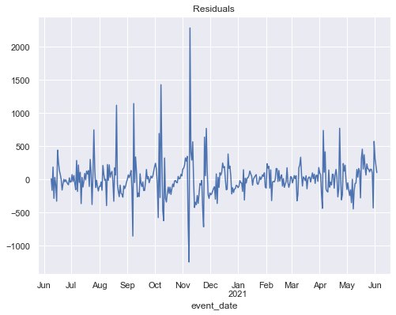

```python
plt.title("Residuals")
model_fit.resid.plot();
plt.show()
```

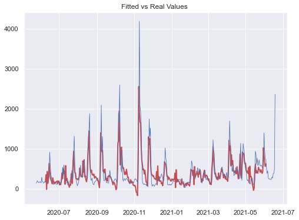

```python
new_df = pd.DataFrame(model_fit.fittedvalues + trend+ season,  index = model_fit.fittedvalues.index)
new_df.columns = ["Fitted"]
new_df["Real"] = sold
plt.plot(random.index,new_df.Fitted, c = "r",linewidth=2)
plt.plot(random.index,new_df.Real, c = "b", linewidth=0.8,)
plt.title("Fitted vs Real Values ")
plt.show()
```

# Task 3 and 4 - Adding external regressors to the model

## 1 ) Searcing for regressors

- In this part, I am going to look for variables that might be correlated to sold amount and can be used as regressors in the ARIMAX model. To do this, first I am going to use pairplots. But some of the data in the columns are lost for so many data points. So only columns I can use for this, "Basket Count" , "Category Sold" , Category Visits" and "Category Favored". I checked the relation of each variable with the sold count. From the visualizations, Basket Count, Category Favored and Category Sold seems to have a correlation, so I am going to add those variables to the model.

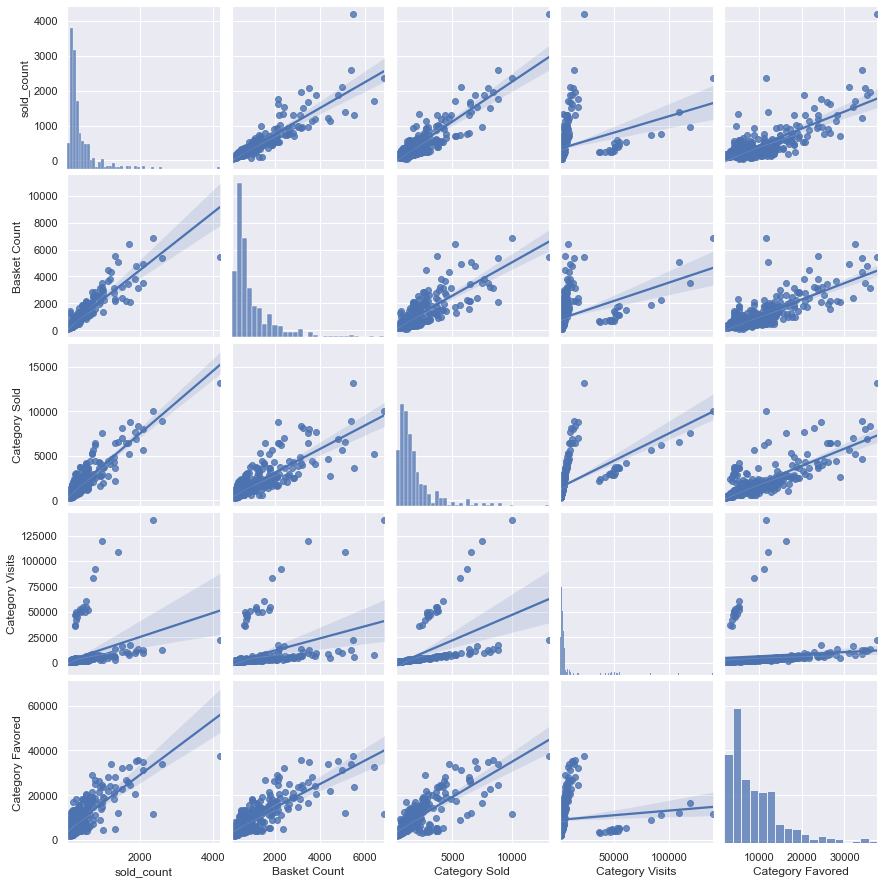

```python
pairplot = pd.DataFrame(pr8["sold_count"])
pairplot["Basket Count"] = pr8["basket_count"]
pairplot["Category Sold"] = pr8["category_sold"]
pairplot["Category Visits"] = pr8["category_visits"]
pairplot["Category Favored"] = pr8["category_favored"]
sns.pairplot(pairplot, kind = "reg");
```

## 2 ) Adding regressors to the ARIMA model

```python
train_data = sold.drop(sold.head(7).index)
train_data.head()
```

| event_date | sold_count |
| --- | --- |
| 2021-06-11 | 230 |
| 2021-06-10 | 253 |
| 2021-06-09 | 244 |
| 2021-06-08 | 249 |
| 2021-06-07 | 266 |

```python
test_data = sold.head(7)
test_data.head()
```

| event_date | sold_count |
| --- | --- |
| 2021-06-18 | 2362 |
| 2021-06-17 | 494 |
| 2021-06-16 | 383 |
| 2021-06-15 | 381 |
| 2021-06-14 | 269 |

```python
regressors = pd.DataFrame(pr8["basket_count"].drop(pr8.head(7).index))
regressors["Category Favored"] = pr8["category_favored"].drop(pr8.head(7).index)
regressors["Category Sold"] = pr8["category_sold"].drop(pr8.head(7).index)
regressors.head()
```

| event_date | basket_count | Category Favored | Category Sold |
| --- | --- | --- | --- |
| 2021-06-11 | 631 | 3054 | 2404 |
| 2021-06-10 | 723 | 3446 | 2670 |
| 2021-06-09 | 717 | 3679 | 2960 |
| 2021-06-08 | 691 | 4665 | 2846 |
| 2021-06-07 | 657 | 3921 | 2863 |

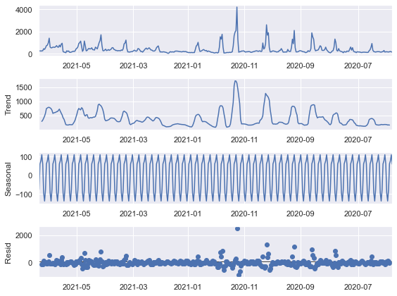

```python
from statsmodels.tsa.seasonal import seasonal_decompose
result = seasonal_decompose(train_data, model='additive', period = 7 )
trend = result.trend
season = result.seasonal
random = result.resid
result.plot();
```